# Module 2. Preparing and exploring longitudinal data in R

Slides

## What this module covers

- Long and wide formats; reshaping with `tidyr`
- Joining participant-level and visit-level files, and validating the join
- Cleaning a messy visit export, with every decision documented
- Missing visits, summary tables and participant flow
- Exploratory plots for longitudinal data
- Why observed means at each visit are not the trajectory we want to estimate

**Simulated data**

All examples use simulated data from fictional studies. Results illustrate methods; they are not empirical findings.

## Learning outcomes

- **2.1** Reshape between long and wide formats with `tidyr`
- **2.2** Join visit- and participant-level files and validate the result
- **2.3** Detect and resolve duplicates, missing visits and timing discrepancies, and document each decision
- **2.4** Produce baseline summaries, visit summaries and a participant-flow table
- **2.5** Construct and interpret spaghetti, trajectory, mean and missingness plots
- **2.6** Explain why observed means differ from model-estimated trajectories under outcome-related dropout

# Long and wide formats

## Long format has one row per observation; wide has one row per participant

```
#> # A tibble: 8 × 6
#>   id    arm   visit month_sched month   sbp
#>   <chr> <fct> <dbl>       <dbl> <dbl> <dbl>
#> 1 W001  EP        1           0  0      150
#> 2 W001  EP        2           1  1.09   148
#> 3 W001  EP        3           3  2.95   133
#> 4 W001  EP        4           6  6.04   140
#> 5 W001  EP        5           9  9.68   132
#> 6 W001  EP        6          12 11.13   132
#> 7 W002  SP        1           0  0      176
#> 8 W002  SP        2           1  1.01   165
```

```
#> # A tibble: 2 × 8
#>   id    arm   sbp_m0 sbp_m1 sbp_m3 sbp_m6 sbp_m9 sbp_m12
#>   <chr> <fct>  <dbl>  <dbl>  <dbl>  <dbl>  <dbl>   <dbl>
#> 1 W001  EP       150    148    133    140    132     132
#> 2 W002  SP       176    165     NA     NA     NA      NA
```

## `pivot_longer()` stacks the visit columns and records the visit

```r
long_from_wide <- wide |>
  pivot_longer(cols = starts_with("sbp_m"),
               names_to = "month_sched", names_prefix = "sbp_m",
               names_transform = list(month_sched = as.numeric),
               values_to = "sbp")
c(rows = nrow(long_from_wide), missing = sum(is.na(long_from_wide$sbp)))
```

```
#>    rows missing
#>    2160     263
```

- 360 participants × 6 visits = 2160 rows
- Dropping the 263 `NA` rows leaves 1897: the number of rows in `walk_long.csv`

## `pivot_wider()` goes back, if only constant columns stay in

```r
wide_again <- walk |>
  select(id, clinic, arm, age, sex, bmi, month_sched, sbp) |>
  pivot_wider(names_from = month_sched, values_from = sbp,
              names_prefix = "sbp_m")
all.equal(as.data.frame(wide_again), as.data.frame(wide),
          check.attributes = FALSE)
```

```
#> [1] TRUE
```

- Leave `month` or `steps` in and you get one row per visit, full of `NA`
- “Values are not uniquely identified” means duplicate keys: fix them, do not average them

## Try it

Workbook **Exercise 1**: reshape `walk_wide.csv` to long format, check it against `walk_long.csv`, and reshape steps to wide format.

# Joining files

## A many-to-one join copies participant data onto every visit

```r
walk_joined <- walk |>
  left_join(baseline |> select(id, rand_date, sbp0, dropout),
            by = "id", relationship = "many-to-one")
c(before = nrow(walk), after = nrow(walk_joined),
  unmatched_visits = nrow(anti_join(walk, baseline, by = "id")),
  never_seen = nrow(anti_join(baseline, walk, by = "id")))
```

```
#>           before            after unmatched_visits       never_seen
#>             1897             1897                0                0
```

- Select only new columns: otherwise `arm.x` and `arm.y`
- Count rows and unmatched keys in both directions

## `relationship =` turns a silent duplication into an error

```r
baseline_bad <- bind_rows(baseline, baseline |> filter(id == "W001"))
tryCatch(
  left_join(walk, baseline_bad |> select(id, rand_date),
            by = "id", relationship = "many-to-one"),
  error = function(e) cat(conditionMessage(e)))
```

```
#> Each row in `x` must match at most 1 row in `y`.
#> ℹ Row 1 of `x` matches multiple rows in `y`.
```

## Try it

Workbook **Exercise 2**: join baseline data to the visits and validate the join.

# Cleaning a raw export

## The raw export has the problems real exports have

```r
raw <- read_csv(here("data", "walk_visits_raw.csv"),
                col_types = cols(.default = col_character()))
head(raw, 4)
```

```
#> # A tibble: 4 × 5
#>   participant visit_label visit_date sbp_mmhg steps_k
#>   <chr>       <chr>       <chr>      <chr>    <chr>
#> 1 W233        M0          2024-01-31 156      5
#> 2 W146        M3          2024-06-16 151      4.5
#> 3 W353        M6          2024-12-26 140      7.5
#> 4 W102        M3          2024-07-09 144      5.6
```

- 1906 rows, but only 1897 attended visits
- Lower-case IDs, text visit labels, SBP as text, a blank, a typing error, duplicates

## Order matters: standardise first, then look for duplicates

```r
step1 <- raw |>
  mutate(id = toupper(trimws(participant)),          # w004 -> W004
         month_sched = as.numeric(sub("^M", "", visit_label)),
         visit = match(month_sched, sched_months),
         visit_date = as.Date(visit_date, format = "%Y-%m-%d"),
         sbp = parse_double(sbp_mmhg),
         steps = parse_double(steps_k))
stopifnot(all(grepl("^W[0-9]{3}$", step1$id)), !anyNA(step1$visit))
```

1. IDs and labels, 2. dates and numbers, 3. exact duplicates, 4. conflicting duplicates, 5. actual time, 6. plausibility, 7. visit windows

## Exact duplicates are removed; conflicting duplicates need a rule

```
#> # A tibble: 6 × 5
#>   id    visit visit_date   sbp steps
#>   <chr> <int> <date>     <dbl> <dbl>
#> 1 W216      2 2024-07-20   143   7.7
#> 2 W216      2 2024-07-22   137   7.7
#> 3 W255      5 2024-12-12   129   7.7
#> 4 W255      5 2024-12-14   139   7.7
#> 5 W290      2 2024-11-21   136   5.9
#> 6 W290      2 2024-11-23   140   5.9
```

- 6 exact duplicate rows: removed with `distinct()`
- 3 visits with two different records
- WALK rule: **keep the earliest-dated record and flag the visit**

## The rule must be fixed without looking at outcomes by arm

- A rule chosen after seeing its effect is part of the analysis
- It can move the treatment effect in the direction the analyst prefers
- Same for outlier rules and visit windows
- Write data-handling rules in the statistical analysis plan before unblinding (Gamble et al. 2017)

## Actual time comes from dates, not from the visit label

$$t_{ij} = \frac{D_{ij} - D^{\text{rand}}_i}{30.44}, \qquad
d_{ij} = D_{ij} - \bigl(D^{\text{rand}}_i + \operatorname{round}(30.44\, s_j)\bigr)$$

```
#> # A tibble: 5 × 5
#>   month_sched window sd_dev max_abs n_out
#>         <dbl>  <dbl>  <dbl>   <dbl> <int>
#> 1           1      7    3.7      12    10
#> 2           3     14    7.7      23    15
#> 3           6     28   10.2      26     0
#> 4           9     28   12.4      37     3
#> 5          12     28   13.6      40     6
```

## One blank and one impossible value

```
#> # A tibble: 2 × 6
#>   id    visit visit_date sbp_raw sbp_flag    steps
#>   <chr> <int> <date>       <dbl> <chr>       <dbl>
#> 1 W088      6 2025-02-20    1190 implausible   4.2
#> 2 W345      1 2024-08-26      NA blank         9.9
```

- Blank: a **missing value at an attended visit**, not a missed visit
- 1190 mmHg: probably 119 typed with an extra zero
- WALK rule: set to missing, keep the raw value, send a query

## The cleaned file agrees with `walk_long.csv`, with two explained exceptions

```
#> # A tibble: 5 × 2
#>   check                      value
#>   <chr>                      <chr>
#> 1 Rows (cleaned / walk_long) 1897 / 1897
#> 2 Keys in only one file      0
#> 3 SBP differs                2
#> 4 Rows where month differs   1068
#> 5 Largest month difference   0.02
```

- SBP: our two `NA` values (blank, implausible)
- Month: dates were rounded to whole days, so differences of up to 0.02 months are expected

## Try it

Workbook **Exercises 3 and 4**: clean the raw export step by step and write the cleaning log.

# Missing visits and summaries

## Build the visit grid from the design, not from the data

```r
grid <- baseline |> select(id, arm) |>
  crossing(visit = 1:6) |>
  mutate(month_sched = sched_months[visit]) |>
  left_join(walk |> select(id, visit, sbp), by = c("id", "visit")) |>
  mutate(observed = !is.na(sbp))
```

```
#> # A tibble: 3 × 4
#>   arm   `after dropout` intermittent observed
#>   <fct>           <int>        <int>    <int>
#> 1 UC                 71           21      628
#> 2 SP                 58           20      642
#> 3 EP                 74           19      627
```

## Participant flow uses the randomised number as denominator

```
#> # A tibble: 6 × 4
#>   month_sched UC         SP         EP
#>         <dbl> <chr>      <chr>      <chr>
#> 1           0 120 (100%) 120 (100%) 120 (100%)
#> 2           1 107 (89%)  107 (89%)  110 (92%)
#> 3           3 106 (88%)  110 (92%)  103 (86%)
#> 4           6 101 (84%)  103 (86%)  105 (88%)
#> 5           9 99 (82%)   102 (85%)  96 (80%)
#> 6          12 95 (79%)   100 (83%)  93 (78%)
```

## Baseline tables describe the arms; they are not tested

```
#> # A tibble: 4 × 4
#>   Characteristic UC           SP           EP
#>   <chr>          <chr>        <chr>        <chr>
#> 1 Age            59.6 (9.4)   60.1 (8.3)   60.5 (9.2)
#> 2 Female, %      54           57           48
#> 3 BMI            28.6 (4.0)   30.0 (4.2)   29.3 (4.4)
#> 4 SBP            146.2 (12.6) 147.2 (14.1) 147.5 (13.2)
```

## Try it

Workbook **Exercise 5**: build the grid, classify missing visits and produce the flow table.

# Exploratory plots

## Spaghetti plots: differences between people dominate

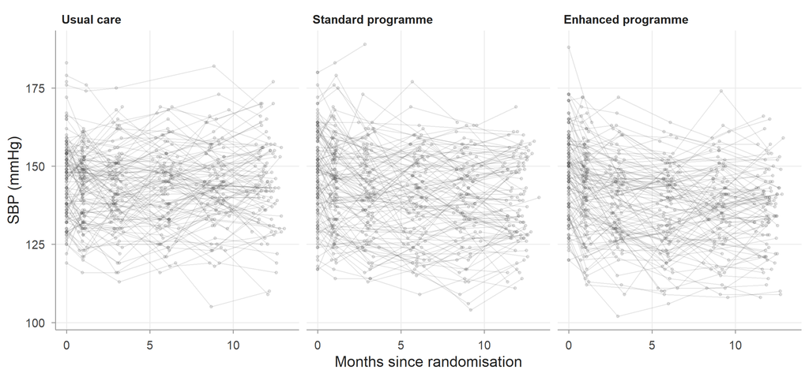

## A random subset shows individual shapes

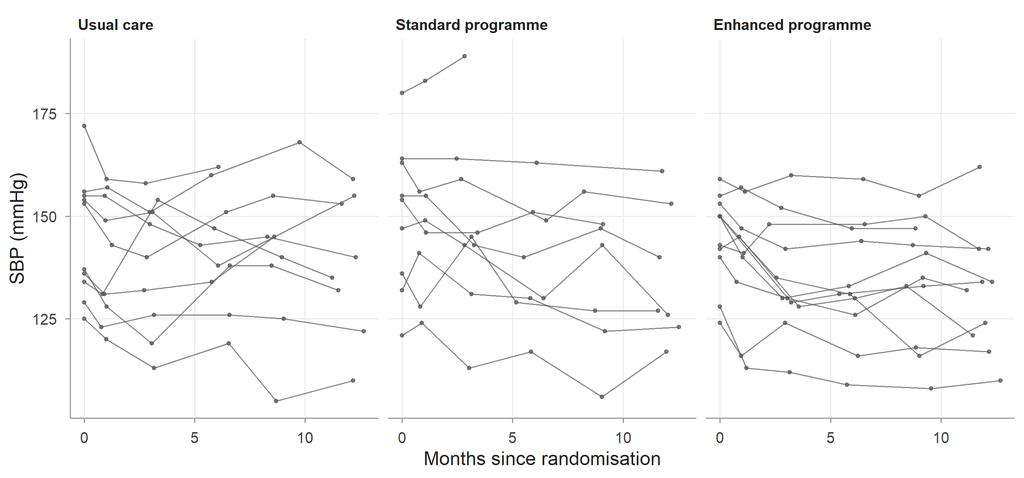

## Observed means suggest an early fall, largest in the enhanced programme

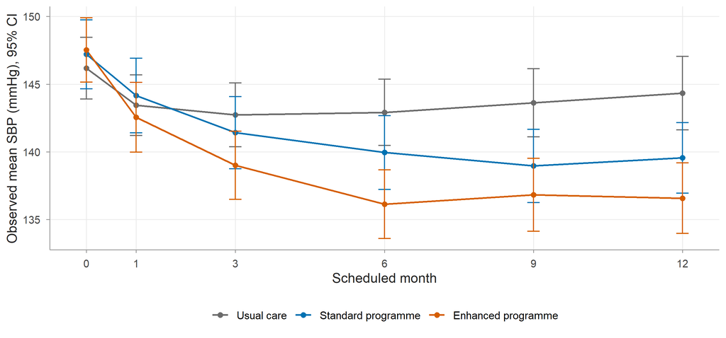

## The missingness map shows dropout as a staircase

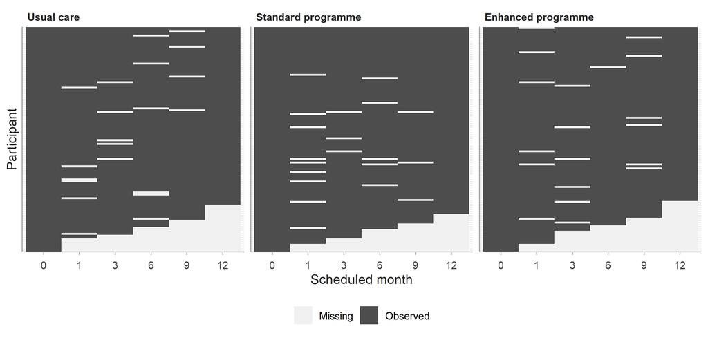

## Participants who dropped out had higher SBP before they left

```
#> # A tibble: 2 × 3
#>   status                        n mean_dev
#>   <chr>                     <int>    <dbl>
#> 1 Seen again later           1537  -0.2402
#> 2 Last visit before dropout    72   5.127
```

- SBP minus the arm mean at the same visit
- Dropouts: on average 5.1 mmHg above their arm’s mean just before leaving

## Try it

Workbook **Exercise 6**: spaghetti plots, individual panels, mean plot, missingness map and pattern plots.

# Observed means versus model estimates

## When higher-SBP participants leave, observed means drift down

$$E(Y_{ij} \mid R_{ij} = 1) \neq E(Y_{ij})$$

- Left: mean of those still measured. Right: mean of everyone randomised
- Under MAR, dropout depends on earlier observed SBP, which is correlated with later SBP
- Those who remain are a selected, healthier group

## Simulated data let us check: observed means are too low, the mixed model is close

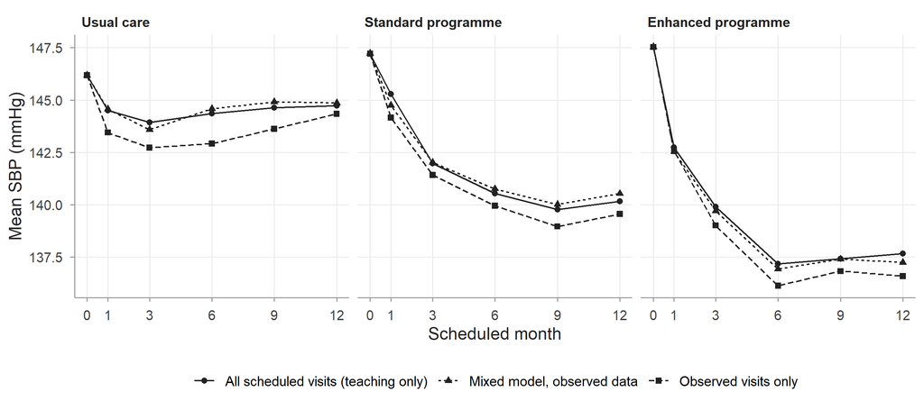

## The mixed model uses each participant’s early values

```r
m_primary <- lmer(sbp ~ visit_f * arm + (1 + month | id),
                  data = walk, control = lmer_ctrl)
emmeans(m_primary, ~ visit_f | arm)
```

- Early measurements tell the model about each participant’s level
- Correlation between visits carries that information forward to missing visits
- Valid under MAR **and** a correct model; not under MNAR (Module 10)

## Summary

- Reshape and join with checks: row counts, keys, `relationship =`
- Clean in a fixed order and log every decision; fix rules before looking at outcomes by arm
- Build the visit grid from the design to see missing visits
- Plot individuals, means, missingness and dropout patterns
- Observed visit means are biased when dropout depends on the outcome; use models fitted to all observed data

## Try it

Workbook **independent exercises 7–10**, then the practical assessment `pa02`.

Gamble, Carrol, Ashma Krishan, Deborah Stocken, et al. 2017. ‘Guidelines for the Content of Statistical Analysis Plans in Clinical Trials’. *JAMA* 318 (23): 2337–43. https://doi.org/10.1001/jama.2017.18556.